# 440 Case Study I Interim Report

Group 8: Jake Epstein, Daniel Spottiswood, Michael Tan, Sahil Patel, Man-Lin Hsiao

9/10/2019

## Introduction

In this report, we will be investigating the relationship between birthweight and various factors. The data we will be analyzing includes children born in North Carolina between 2011 and 2016, totaling 720,000 observations. In addition to birthweight, this data includes factors such as sex, gestation period, smoking behavior, mother’s race, and county of residence, which we used as a proxy for mother’s socioeconomic status. We will first explore each of these variables and determine which factors are relevant to birthweight, and then use the relevant factors to create, evaluate and interpret a linear regression model. We will also use M-estimation to create a more robust model. Finally, we will use cross-validation to compare our chosen linear model with the more robust version.

## Exploratory Data Analysis

### Birthweight

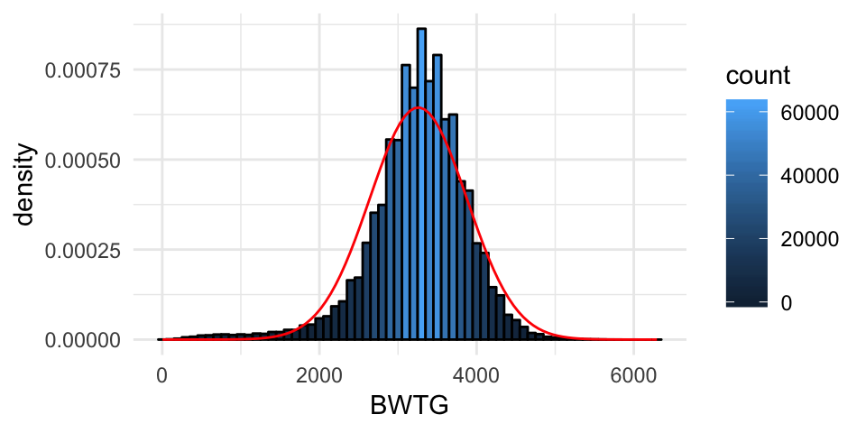

Birthweight is close to normally distrubted, with a slight left skew, centered around ~3,300g with a standard deviation of 600g. There appear to be no large outliers in terms of birthweight. 430 birth weights are missing. We see that the left tail is much larger than we would expect in a normal distribution. We’ll keep this in mind when evaluating the assumptions of linear regression.

### Sex

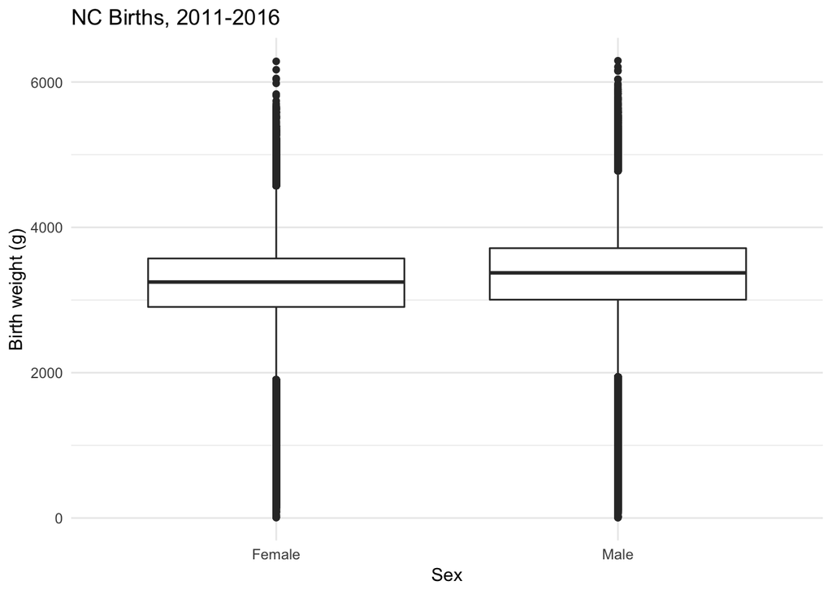

```
## # A tibble: 2 x 2
##   SEX    `Average Birthweight`
##   <chr>                  <dbl>
## 1 Female                 3199.
## 2 Male                   3315.
```

On average, males in our data are about 100g heavier than females at birth.

### Smoking

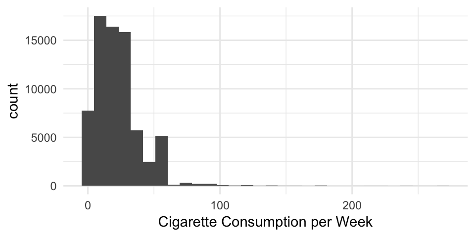

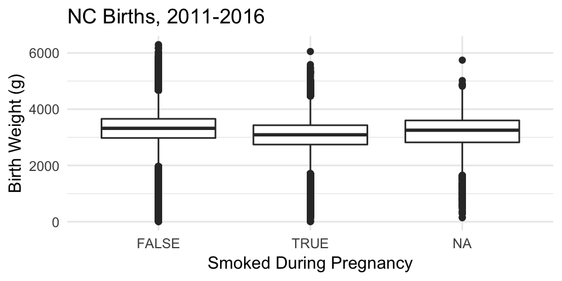

```
## # A tibble: 4 x 2
##   smoking_type      `Average Birthweight`
##   <fct>                             <dbl>
## 1 none                              3282.
## 2 before and during                 3050.
## 3 before only                       3268.
## 4 during only                       3058.
```

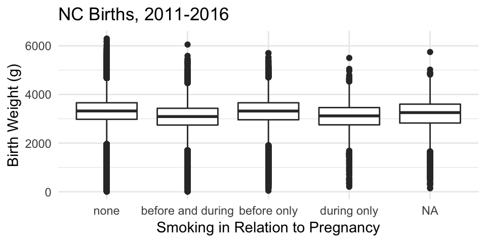

Because the average cigarette consumption in our data varied quite a bit, and because this data was likely self-reported, we chose to simplify our analysis on smoking and chose to turn smoking into a categorical variable, with mothers classified as either 1) non-smokers, 2) those who only smoked before pregnancy, 3) those who smoked during but not before pregnancy, and 4) those who smoked throughout.  
Around 13% of women smoked in the three months leading up to pregnancy and around 10% of women smoked at any point during their pregnancy. Among those who did smoke during pregnancy, the average number of cigarettes smoked during pregnancy was 23. The birthweight of children of mothers who smoked before and during pregnancy was significantly lower than that of the children of nonsmokers, with an average difference of about 200 grams. There is also a significant relationship between birthweight and smoking before pregnancy, even for those who did not smoke during pregnancy.

### Parity

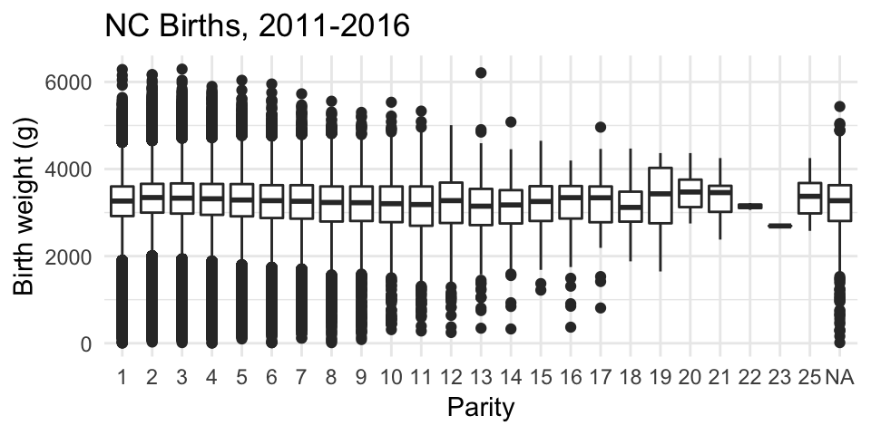

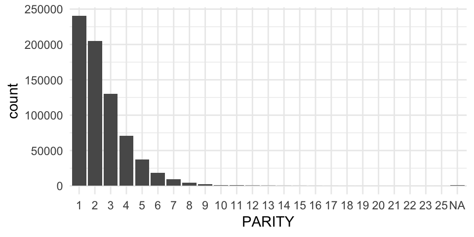

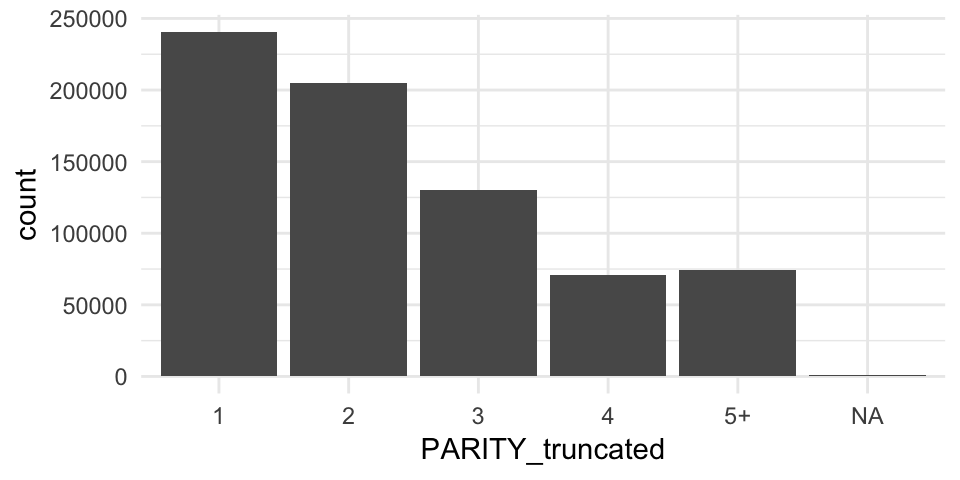

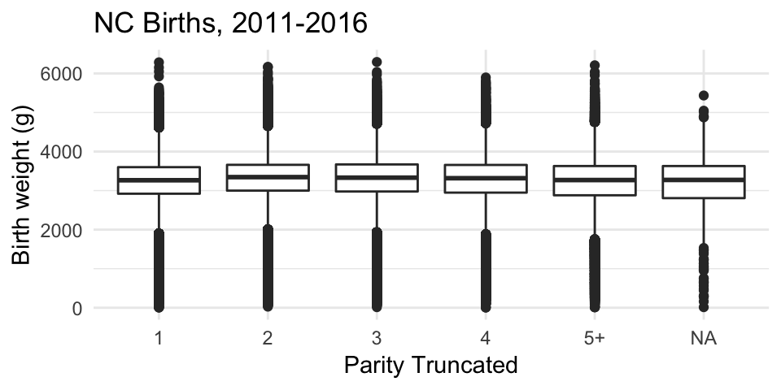

Independent of other variables, we see a negative relationship between parity and birth weight past the first child. The frequency of parity decreases in an exponential fashion. A second variable was created that truncates parities of at least five to improve interprability and prevent overfitting. The quantity of missing data is relatively small, as there are very few instances of mothers having more than 5 children.

### Plurality

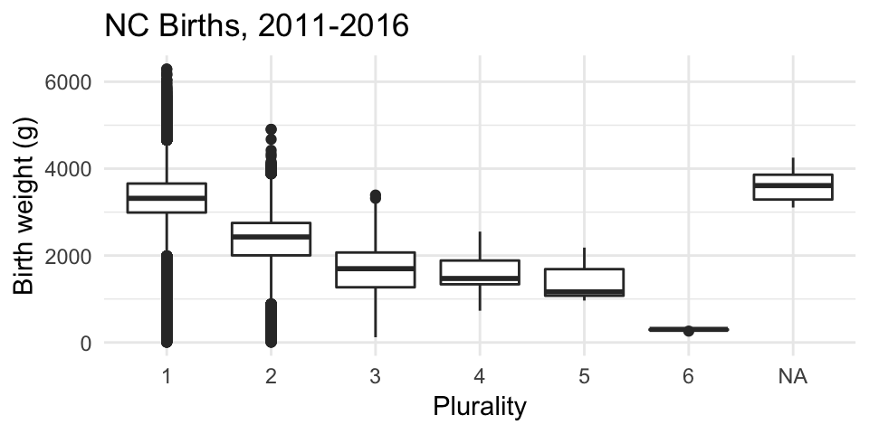

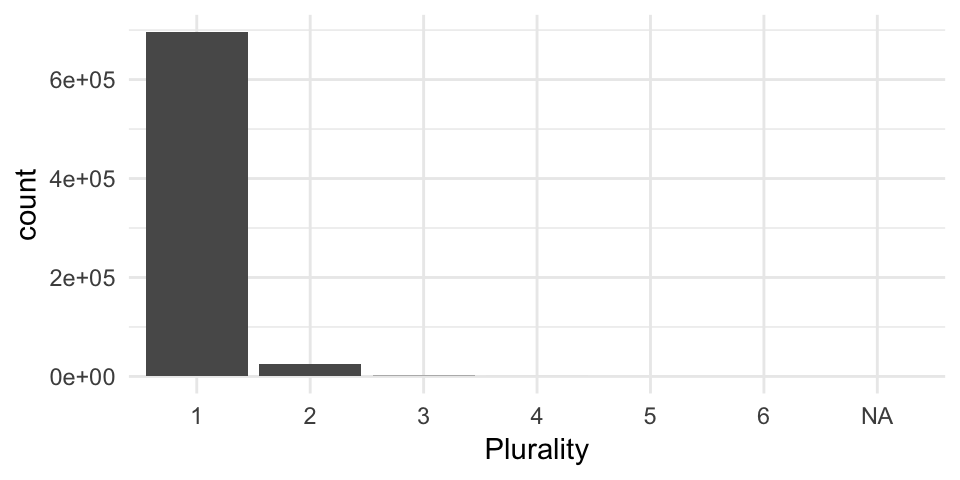

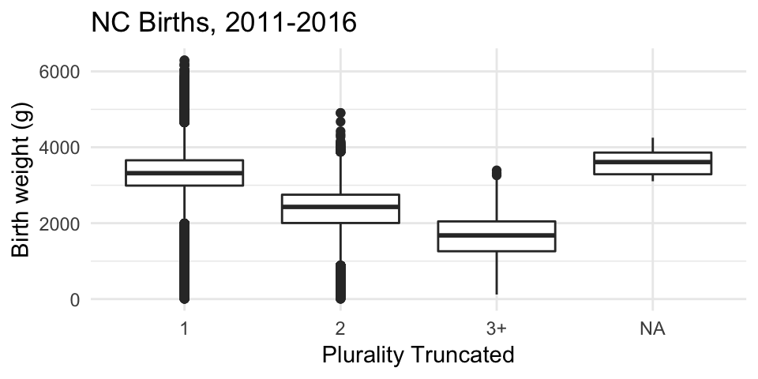

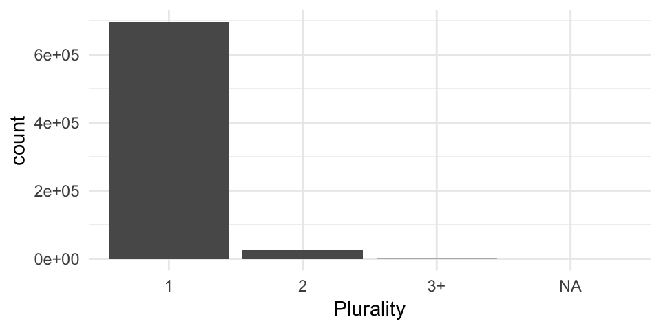

We see a strong non-linear negative relationship between plurality and birth weight. The frequency of pluralities above two is extremely small, and we again see a proportionally small amount of missing data (very few mothers have triplets or more). A second variable was created that truncates pluralities of at least three to improve interprability and prevent overfitting.

### Gestation

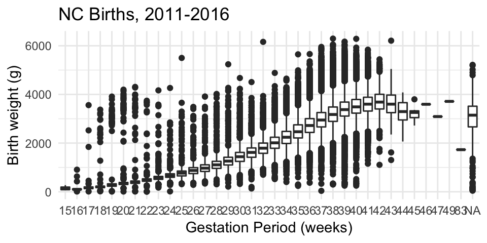

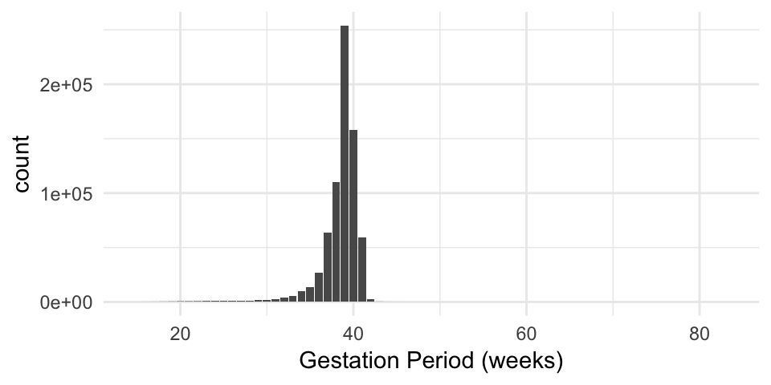

There appears to be a non-linear positive relationship between gestation period and birth weight. The mean gestational period is approximately 38.5 weeks and the period with the highest median weight is 42 weeks. The frequency distribution is left skewed with the majority of babies having a gestational period between 38 and 40 weeks. There is some concern that more extreme gestational periods may lead to higher variance, and it should be noted that there is a chunk of data points with gestational periods of 17 to 21 weeks that have much higher than expected birth weights. There is an extreme outlier with gestational age of 83 weeks. Given that this data point was probably incorrectly recorded (it is biologically nearly impossible for a human to gestate for 83 weeks), we will exclude it from our analysis when building the model.

### Age of Mother

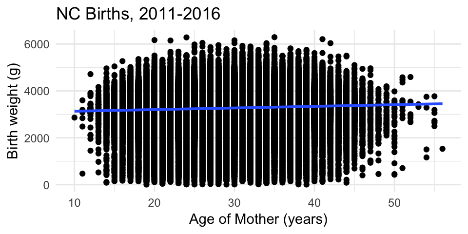

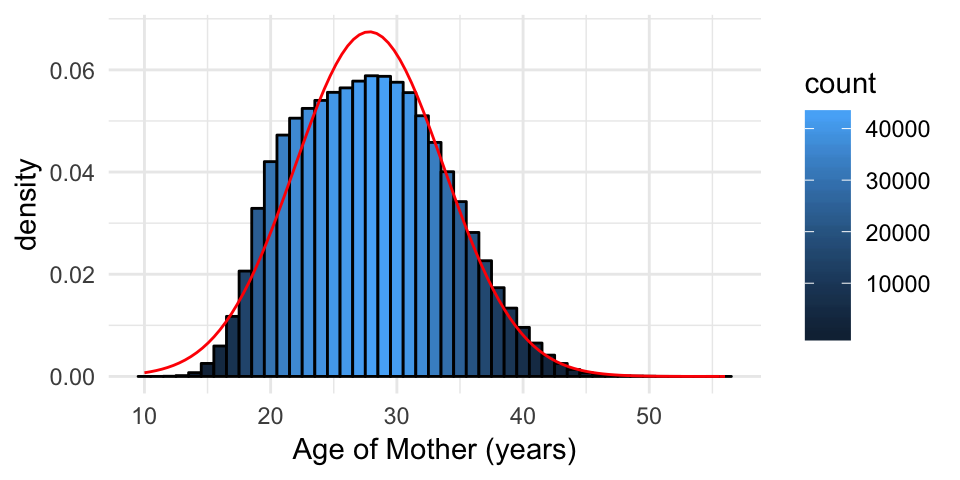

Mother’s age seems to be fairly normally distributed with a mean of 27.7, with a slightly shorter left tail. There appears to be a positive relationship between the age of the mother and the birth weight. There is no evidence to suggest that the birth weight variance is not constant across the mother’s age.

### Race of Mother

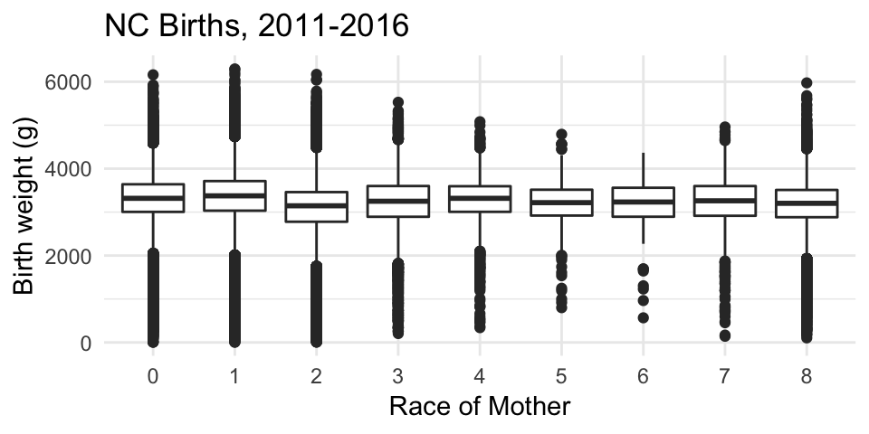

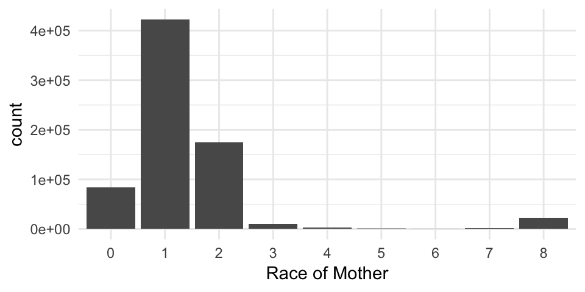

0 - Other non-White  
1 - White  
2 - Black or African American  
3 - American Indian or Alaska Native  
4 - Chinese  
5 - Japanese  
6 - Native Hawaiian  
7 - Filipino  
8 - Other Asian

There are significant differences between the average birth weights of mothers of different races. We see that mothers that self-identified as white have the largest mean baby weight at 3.33 kg, while black mothers have the lowest mean baby weight at only 3.07 kg. 58 percent of mothers identify as white, 24 percent identify as black, 12 percent identify as other non-white, and 3 percent identify as other asian.

### County / Socioeconomic Status

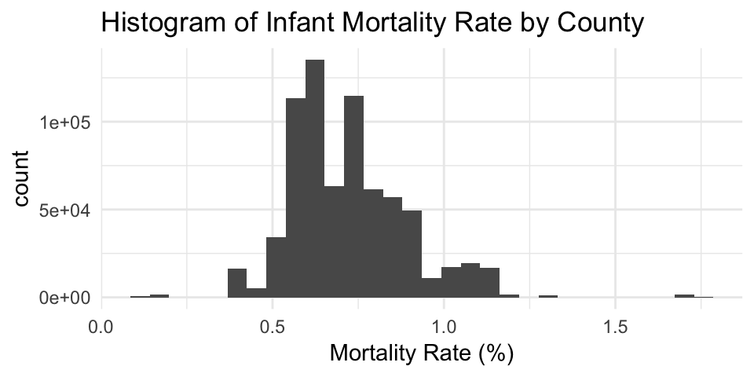

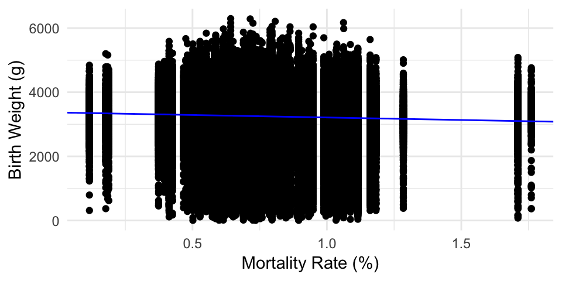

We chose to use infant mortality rate of birth county as a proxy for socioeconomic status, calculated as number of deaths before the age of 1 divided by total number of births in a county. The median county in the data had a infant mortality rate of 0.7%, with the range of infant mortality rates in our dataset ranging from 0.12% to 1.76%. Infant mortality rate of birth county and birth weight appear to have a weak negative linear relationship, and in isolation, a 1 percentage point increase in infant mortality rate is associated with a 157g decrease in expected birth weight.

## Model Building and Selection

### Model 1: Initial Approach

```
##
## Call:
## lm(formula = BWTG ~ SEX + GEST + PARITY_truncated + PLUR_truncated +
##     smoking_type + MAGE + MRACER + mortality, data = births_excl,
##     na.action = "na.exclude")
##
## Residuals:
##     Min      1Q  Median      3Q     Max
## -3467.4  -279.1   -19.0   257.6  4823.5
##
## Coefficients:
##                                 Estimate Std. Error  t value Pr(>|t|)
## (Intercept)                   -3.771e+03  9.845e+00 -383.086  < 2e-16 ***
## SEXMale                        1.245e+02  1.002e+00  124.296  < 2e-16 ***
## GEST                           1.756e+02  2.312e-01  759.667  < 2e-16 ***
## PARITY_truncated2              9.470e+01  1.302e+00   72.719  < 2e-16 ***
## PARITY_truncated3              1.139e+02  1.522e+00   74.830  < 2e-16 ***
## PARITY_truncated4              1.176e+02  1.906e+00   61.698  < 2e-16 ***
## PARITY_truncated5+             1.184e+02  1.933e+00   61.247  < 2e-16 ***
## PLUR_truncated2               -3.592e+02  2.900e+00 -123.844  < 2e-16 ***
## PLUR_truncated3+              -4.469e+02  1.523e+01  -29.335  < 2e-16 ***
## smoking_typebefore and during -2.049e+02  1.751e+00 -116.998  < 2e-16 ***
## smoking_typebefore only       -1.105e+01  2.674e+00   -4.131 3.61e-05 ***
## smoking_typeduring only       -1.631e+02  9.033e+00  -18.055  < 2e-16 ***
## MAGE                           4.606e+00  9.538e-02   48.291  < 2e-16 ***
## MRACER1                        8.249e+01  1.642e+00   50.235  < 2e-16 ***
## MRACER2                       -9.933e+01  1.801e+00  -55.141  < 2e-16 ***
## MRACER3                       -5.746e+00  4.527e+00   -1.269   0.2044
## MRACER4                       -3.328e+01  7.521e+00   -4.425 9.62e-06 ***
## MRACER5                       -1.091e+02  1.775e+01   -6.147 7.90e-10 ***
## MRACER6                        2.183e+01  4.356e+01    0.501   0.6163
## MRACER7                       -1.711e+01  9.358e+00   -1.828   0.0675 .
## MRACER8                       -1.035e+02  3.174e+00  -32.610  < 2e-16 ***
## mortality                      2.391e+01  3.069e+00    7.790 6.71e-15 ***
## ---
## Signif. codes:  0 '***' 0.001 '**' 0.01 '*' 0.05 '.' 0.1 ' ' 1
##
## Residual standard error: 424.3 on 717847 degrees of freedom
## Multiple R-squared:  0.5286, Adjusted R-squared:  0.5285
## F-statistic: 3.832e+04 on 21 and 717847 DF,  p-value: < 2.2e-16
```

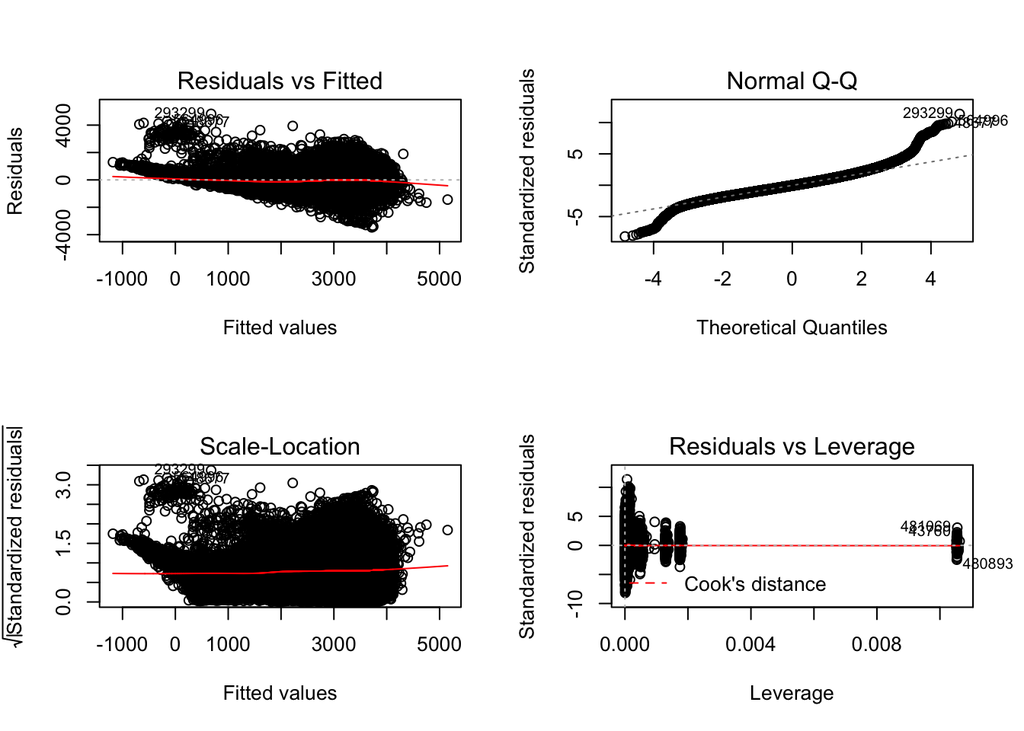

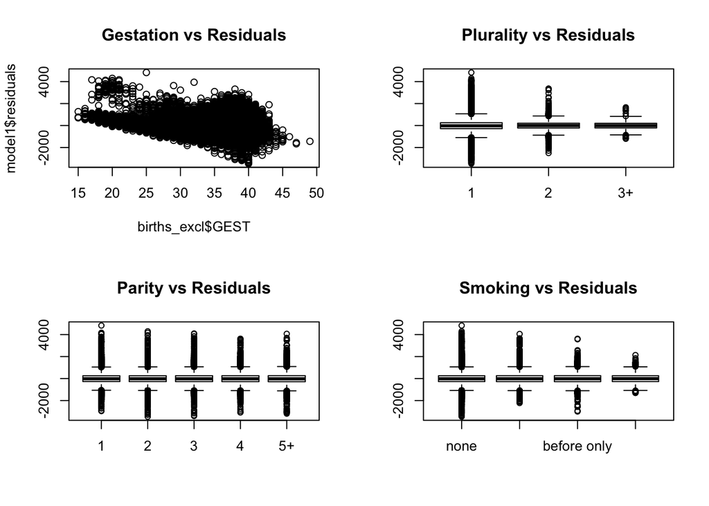

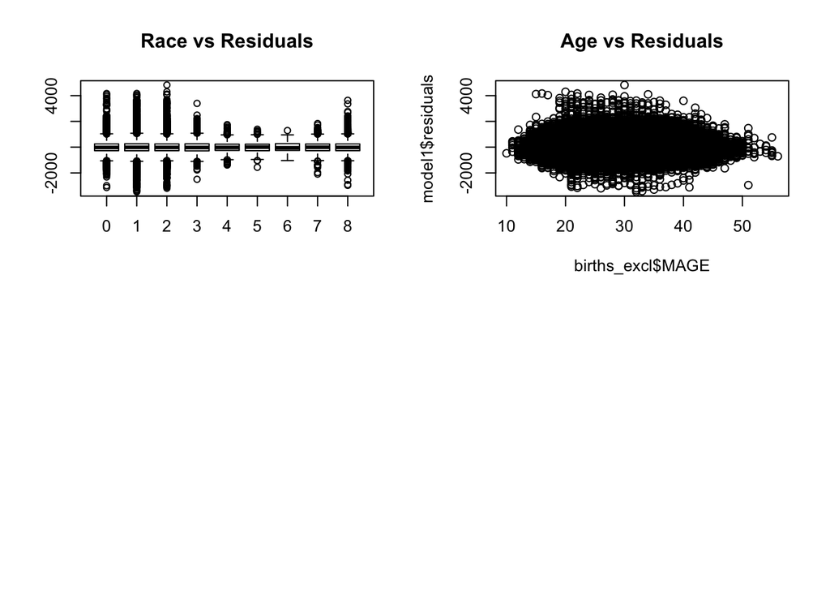

The residuals vs fitted values and residuals vs gestational period plot slope downwards, indicating that there is a departure from linearity. A transformation may be helpful. The model may improve if a square term is added for gestation. Furthermore, the Q-Q plot indicates a departure from normality, likely as a result of the left skew of birthweight. We will keep this in mind as we make improvements to this initial model.  
The residual graph for Plurality (truncated) has decreasing residuals (in terms of absolute value) as plurality increases. This makes sense, as birth weight should get smaller (and as a result range of birth weights should get tighter, leading to smaller absolute value residuals) as more babies share a womb and share nutrients – More sharing will biologically cause them to come out smaller.  
The residual graph for Parity (truncated) has pretty random residuals that are all around the same size for each group.  
The residual graph for Smoking has higher residuals for no smoking than for smoking of any kind. This makes sense, as birth weight could biologically get smaller in the presence of smoking, as smoking can be damaging to the fetus and be detrimental to its growth and weight. This would lead to the range of birth weights of smoking mothers getting tighter, leading to smaller absolute value residuals.  
The residual graph for Mother’s race indicates that residuals are lower for for races 3, 4, 5, 6, and 7 and higher for the other races. This could be something to explore.  
The residual graph for Mother’s age is fairly random, with residuals getting a bit smaller near the beginning and end (<20 years old and >45 years old).

### Model 2: Quadratic Term Added

```
##
## Call:
## lm(formula = BWTG ~ SEX + GEST + GEST2 + PARITY_truncated + PLUR_truncated +
##     smoking_type + MAGE + MRACER + mortality, data = births_excl,
##     na.action = "na.exclude")
##
## Residuals:
##     Min      1Q  Median      3Q     Max
## -3473.3  -279.1   -19.1   257.5  4776.8
##
## Coefficients:
##                                 Estimate Std. Error  t value Pr(>|t|)
## (Intercept)                   -2.987e+03  4.004e+01  -74.617  < 2e-16 ***
## SEXMale                        1.247e+02  1.002e+00  124.457  < 2e-16 ***
## GEST                           1.293e+02  2.302e+00   56.175  < 2e-16 ***
## GEST2                          6.688e-01  3.311e-02   20.202  < 2e-16 ***
## PARITY_truncated2              9.598e+01  1.303e+00   73.635  < 2e-16 ***
## PARITY_truncated3              1.154e+02  1.523e+00   75.786  < 2e-16 ***
## PARITY_truncated4              1.195e+02  1.907e+00   62.641  < 2e-16 ***
## PARITY_truncated5+             1.205e+02  1.935e+00   62.259  < 2e-16 ***
## PLUR_truncated2               -3.538e+02  2.912e+00 -121.525  < 2e-16 ***
## PLUR_truncated3+              -4.486e+02  1.523e+01  -29.455  < 2e-16 ***
## smoking_typebefore and during -2.041e+02  1.751e+00 -116.562  < 2e-16 ***
## smoking_typebefore only       -1.109e+01  2.673e+00   -4.149 3.34e-05 ***
## smoking_typeduring only       -1.628e+02  9.030e+00  -18.028  < 2e-16 ***
## MAGE                           4.629e+00  9.536e-02   48.543  < 2e-16 ***
## MRACER1                        8.271e+01  1.642e+00   50.382  < 2e-16 ***
## MRACER2                       -9.902e+01  1.801e+00  -54.981  < 2e-16 ***
## MRACER3                       -6.053e+00  4.526e+00   -1.337   0.1811
## MRACER4                       -3.313e+01  7.519e+00   -4.407 1.05e-05 ***
## MRACER5                       -1.083e+02  1.775e+01   -6.100 1.06e-09 ***
## MRACER6                        2.156e+01  4.355e+01    0.495   0.6206
## MRACER7                       -1.545e+01  9.356e+00   -1.651   0.0987 .
## MRACER8                       -1.025e+02  3.173e+00  -32.315  < 2e-16 ***
## mortality                      2.465e+01  3.068e+00    8.034 9.42e-16 ***
## ---
## Signif. codes:  0 '***' 0.001 '**' 0.01 '*' 0.05 '.' 0.1 ' ' 1
##
## Residual standard error: 424.2 on 717846 degrees of freedom
## Multiple R-squared:  0.5288, Adjusted R-squared:  0.5288
## F-statistic: 3.662e+04 on 22 and 717846 DF,  p-value: < 2.2e-16
```

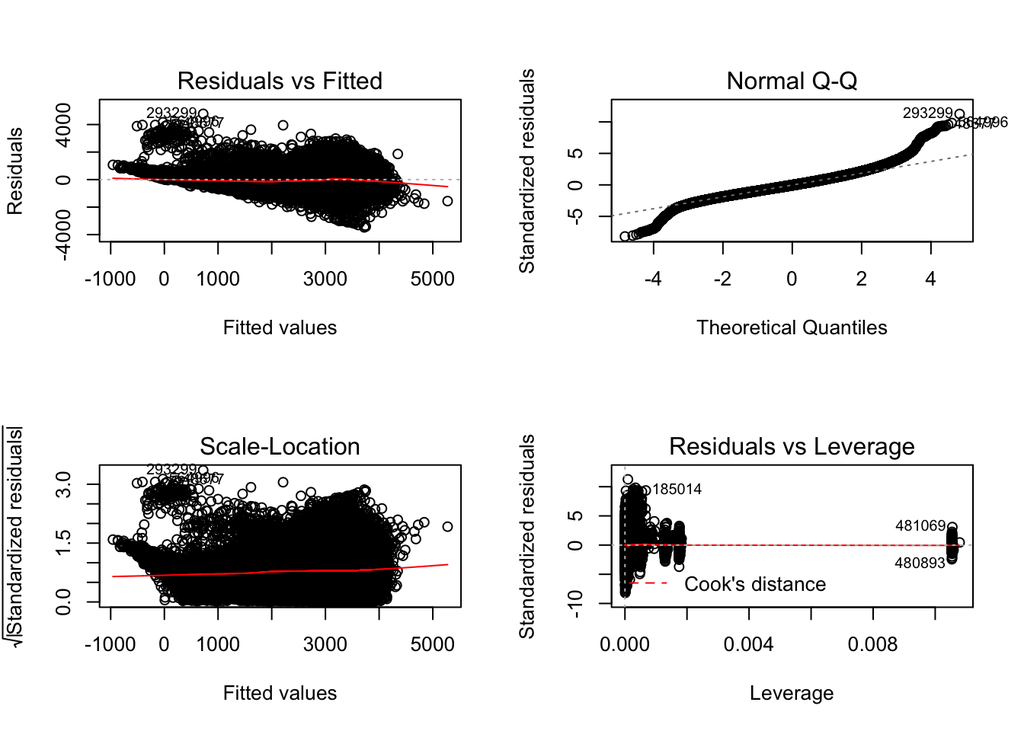

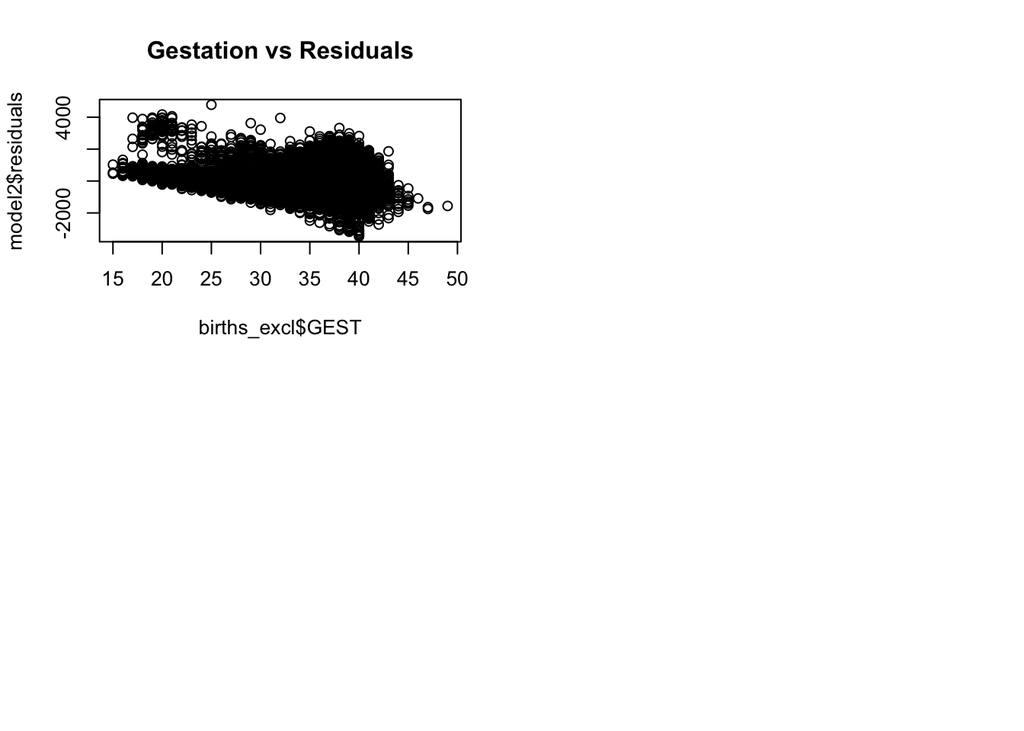

For the next iteration of the model, we added a quadratic term for gestation. While the quadratic term is statistically significant, the new model still displays the original downwards trend in the residual vs gestational period graph. Perhaps another transformation on gestation would be helpful – a cubic term can be added. The other residuals plots also retain their trends from model 1.

### Model 3: Cubic Term Added

```
##
## Call:
## lm(formula = BWTG ~ SEX + GEST + GEST2 + GEST3 + PARITY_truncated +
##     PLUR_truncated + smoking_type + MAGE + MRACER + mortality,
##     data = births_excl, na.action = "na.exclude")
##
## Residuals:
##     Min      1Q  Median      3Q     Max
## -3458.0  -276.5   -18.6   255.0  4941.9
##
## Coefficients:
##                                 Estimate Std. Error  t value Pr(>|t|)
## (Intercept)                    1.694e+04  1.846e+02   91.773  < 2e-16 ***
## SEXMale                        1.246e+02  9.933e-01  125.413  < 2e-16 ***
## GEST                          -1.784e+03  1.746e+01 -102.187  < 2e-16 ***
## GEST2                          6.010e+01  5.386e-01  111.580  < 2e-16 ***
## GEST3                         -6.012e-01  5.438e-03 -110.544  < 2e-16 ***
## PARITY_truncated2              8.820e+01  1.294e+00   68.143  < 2e-16 ***
## PARITY_truncated3              1.060e+02  1.513e+00   70.070  < 2e-16 ***
## PARITY_truncated4              1.104e+02  1.893e+00   58.332  < 2e-16 ***
## PARITY_truncated5+             1.125e+02  1.920e+00   58.611  < 2e-16 ***
## PLUR_truncated2               -3.283e+02  2.896e+00 -113.372  < 2e-16 ***
## PLUR_truncated3+              -3.407e+02  1.513e+01  -22.510  < 2e-16 ***
## smoking_typebefore and during -2.033e+02  1.736e+00 -117.113  < 2e-16 ***
## smoking_typebefore only       -1.087e+01  2.651e+00   -4.102 4.10e-05 ***
## smoking_typeduring only       -1.628e+02  8.954e+00  -18.184  < 2e-16 ***
## MAGE                           4.610e+00  9.456e-02   48.754  < 2e-16 ***
## MRACER1                        8.152e+01  1.628e+00   50.079  < 2e-16 ***
## MRACER2                       -9.965e+01  1.786e+00  -55.803  < 2e-16 ***
## MRACER3                       -3.018e+00  4.488e+00   -0.672   0.5014
## MRACER4                       -3.801e+01  7.456e+00   -5.097 3.44e-07 ***
## MRACER5                       -1.132e+02  1.760e+01   -6.432 1.26e-10 ***
## MRACER6                        2.174e+01  4.318e+01    0.503   0.6146
## MRACER7                       -2.168e+01  9.277e+00   -2.337   0.0194 *
## MRACER8                       -1.075e+02  3.147e+00  -34.164  < 2e-16 ***
## mortality                      2.027e+01  3.043e+00    6.662 2.70e-11 ***
## ---
## Signif. codes:  0 '***' 0.001 '**' 0.01 '*' 0.05 '.' 0.1 ' ' 1
##
## Residual standard error: 420.6 on 717845 degrees of freedom
## Multiple R-squared:  0.5367, Adjusted R-squared:  0.5367
## F-statistic: 3.616e+04 on 23 and 717845 DF,  p-value: < 2.2e-16
```

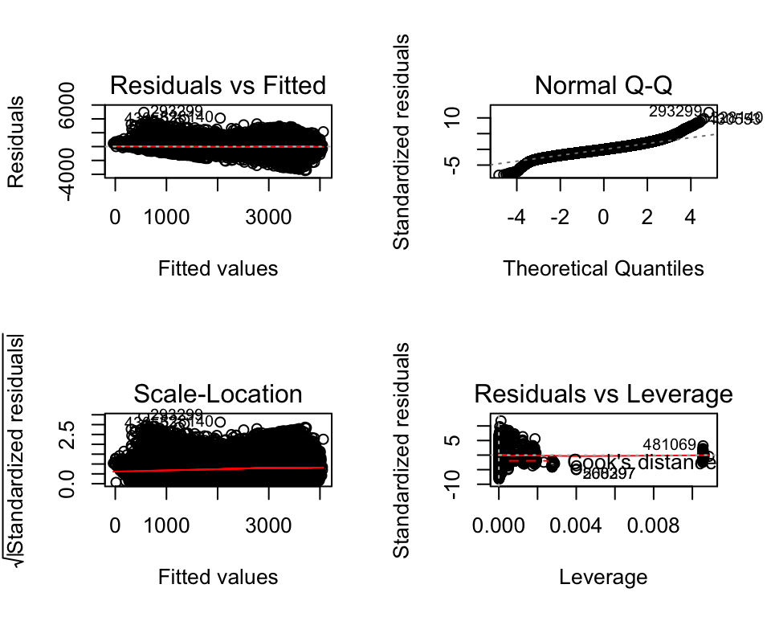

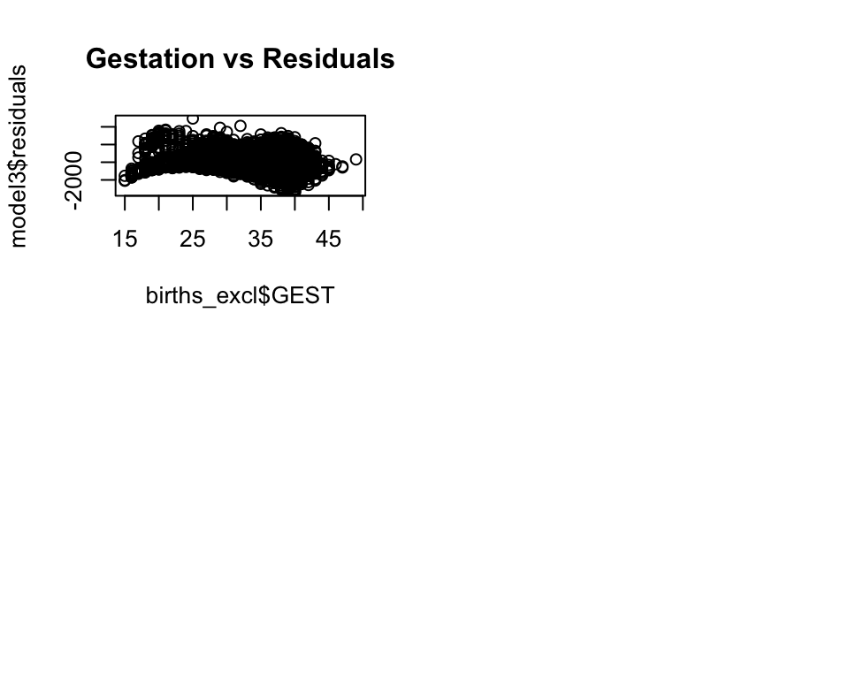

After adding a cubic term to gestation, the residual vs gestational period shows a much more random pattern than before and the cubic term is statistically significant. It is worth investigating if adding a quartic term would help. The other residuals plots also retain their trends from model 1.

### Model 4: Quartic Term Added

```
##
## Call:
## lm(formula = BWTG ~ SEX + GEST + GEST2 + GEST3 + GEST4 + PARITY_truncated +
##     PLUR_truncated + smoking_type + MAGE + MRACER + mortality,
##     data = births_excl, na.action = "na.exclude")
##
## Residuals:
##     Min      1Q  Median      3Q     Max
## -3459.5  -276.4   -19.1   254.2  4805.8
##
## Coefficients:
##                                 Estimate Std. Error  t value Pr(>|t|)
## (Intercept)                   -1.696e+04  7.563e+02  -22.430  < 2e-16 ***
## SEXMale                        1.250e+02  9.919e-01  126.038  < 2e-16 ***
## GEST                           2.759e+03  9.983e+01   27.641  < 2e-16 ***
## GEST2                         -1.624e+02  4.843e+00  -33.529  < 2e-16 ***
## GEST3                          4.134e+00  1.026e-01   40.299  < 2e-16 ***
## GEST4                         -3.707e-02  8.021e-04  -46.224  < 2e-16 ***
## PARITY_truncated2              8.560e+01  1.294e+00   66.168  < 2e-16 ***
## PARITY_truncated3              1.032e+02  1.512e+00   68.297  < 2e-16 ***
## PARITY_truncated4              1.080e+02  1.891e+00   57.110  < 2e-16 ***
## PARITY_truncated5+             1.110e+02  1.917e+00   57.905  < 2e-16 ***
## PLUR_truncated2               -3.130e+02  2.911e+00 -107.511  < 2e-16 ***
## PLUR_truncated3+              -3.212e+02  1.512e+01  -21.249  < 2e-16 ***
## smoking_typebefore and during -2.024e+02  1.734e+00 -116.729  < 2e-16 ***
## smoking_typebefore only       -1.070e+01  2.647e+00   -4.042 5.30e-05 ***
## smoking_typeduring only       -1.624e+02  8.941e+00  -18.168  < 2e-16 ***
## MAGE                           4.610e+00  9.442e-02   48.826  < 2e-16 ***
## MRACER1                        8.110e+01  1.625e+00   49.895  < 2e-16 ***
## MRACER2                       -9.986e+01  1.783e+00  -56.004  < 2e-16 ***
## MRACER3                       -2.682e+00  4.481e+00   -0.598   0.5496
## MRACER4                       -4.009e+01  7.445e+00   -5.384 7.27e-08 ***
## MRACER5                       -1.151e+02  1.757e+01   -6.551 5.70e-11 ***
## MRACER6                        1.988e+01  4.312e+01    0.461   0.6447
## MRACER7                       -2.249e+01  9.264e+00   -2.428   0.0152 *
## MRACER8                       -1.087e+02  3.142e+00  -34.603  < 2e-16 ***
## mortality                      1.886e+01  3.039e+00    6.207 5.41e-10 ***
## ---
## Signif. codes:  0 '***' 0.001 '**' 0.01 '*' 0.05 '.' 0.1 ' ' 1
##
## Residual standard error: 420 on 717844 degrees of freedom
## Multiple R-squared:  0.5381, Adjusted R-squared:  0.5381
## F-statistic: 3.484e+04 on 24 and 717844 DF,  p-value: < 2.2e-16
```

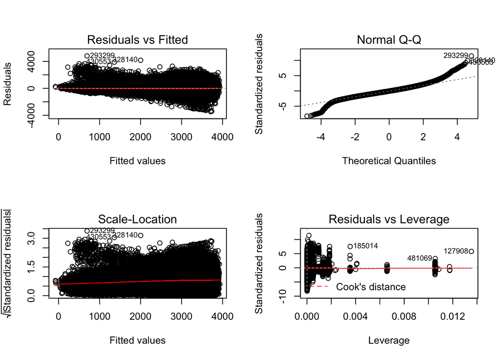

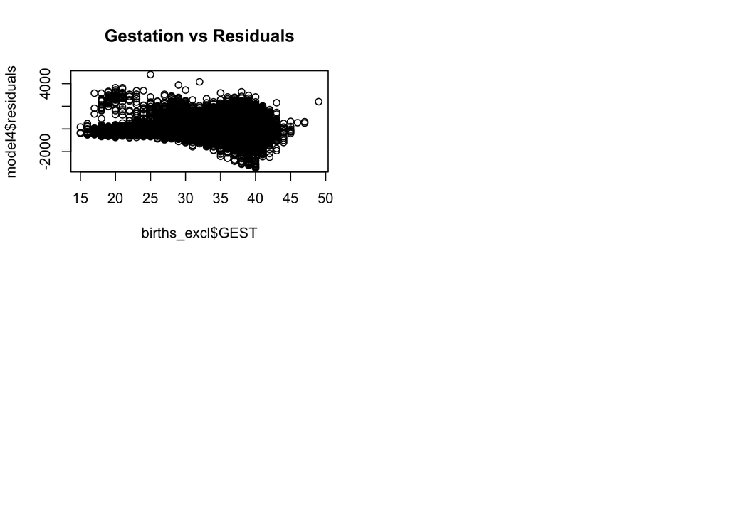

The addition of the quartic term does seem to help a bit, and it seems that we’ve gone as far as we can go with polynomial terms on gestation. Despite this, our assumption of normality still does not appear to be totally met, as shown by the Q-Q plot, and the residuals are not quite homoskedastic, as the variance of the residuals increases as the fitted values gets larger. Because of this, we should look into more robust methods. For that we will utilize M-estimation.

### Robust on Model 4

```
##
## Call: rlm(formula = BWTG ~ SEX + GEST + GEST2 + GEST3 + GEST4 + PARITY_truncated +
##     PLUR_truncated + smoking_type + MAGE + MRACER + mortality,
##     data = births_excl, na.action = "na.exclude")
## Residuals:
##      Min       1Q   Median       3Q      Max
## -3450.59  -265.15    -7.99   264.72  4851.99
##
## Coefficients:
##                               Value       Std. Error  t value
## (Intercept)                   -20832.5288    737.0438    -28.2650
## SEXMale                          125.8927      0.9667    130.2333
## GEST                            3198.1057     97.2893     32.8721
## GEST2                           -181.0673      4.7199    -38.3622
## GEST3                              4.4858      0.1000     44.8691
## GEST4                             -0.0395      0.0008    -50.5839
## PARITY_truncated2                 83.8875      1.2608     66.5368
## PARITY_truncated3                101.4576      1.4733     68.8641
## PARITY_truncated4                106.8853      1.8429     57.9985
## PARITY_truncated5+               108.7941      1.8686     58.2233
## PLUR_truncated2                 -291.9323      2.8370   -102.9025
## PLUR_truncated3+                -292.4886     14.7333    -19.8522
## smoking_typebefore and during   -200.8456      1.6897   -118.8671
## smoking_typebefore only          -10.9530      2.5795     -4.2462
## smoking_typeduring only         -159.0316      8.7136    -18.2509
## MAGE                               4.4408      0.0920     48.2603
## MRACER1                           84.1034      1.5841     53.0928
## MRACER2                          -98.5692      1.7378    -56.7212
## MRACER3                           -5.5367      4.3674     -1.2677
## MRACER4                          -37.1367      7.2557     -5.1183
## MRACER5                         -109.4439     17.1237     -6.3914
## MRACER6                           17.2574     42.0223      0.4107
## MRACER7                          -18.0603      9.0280     -2.0005
## MRACER8                         -107.3517      3.0626    -35.0528
## mortality                         19.2767      2.9613      6.5096
##
## Residual standard error: 392.8 on 717844 degrees of freedom
```

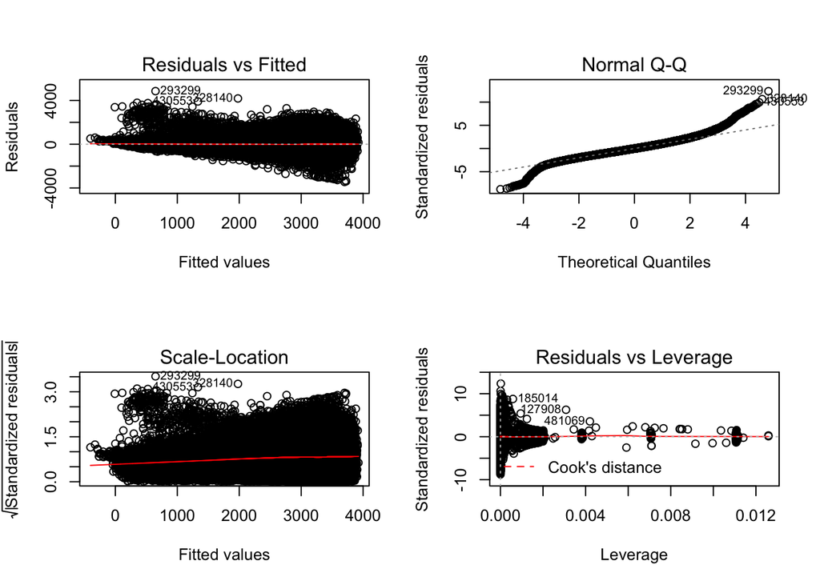

```
##         bwt gest      resid    weight
## 293299 5500   25 4851.98909 0.1088920
## 328140 6160   32 4181.05135 0.1263676
## 430553 5239   29 3905.43669 0.1352848
## 564996 4139   20 3788.42654 0.1394626
## 48677  4281   21 3756.24824 0.1406568
## 717861 3289   39  -26.98030 1.0000000
## 717862 3770   41   69.51248 1.0000000
## 717863 2872   39 -318.08757 1.0000000
## 717864 3360   38  115.04857 1.0000000
## 717866 3713   40  128.33306 1.0000000
## 717867 3180   39 -354.58919 1.0000000
```

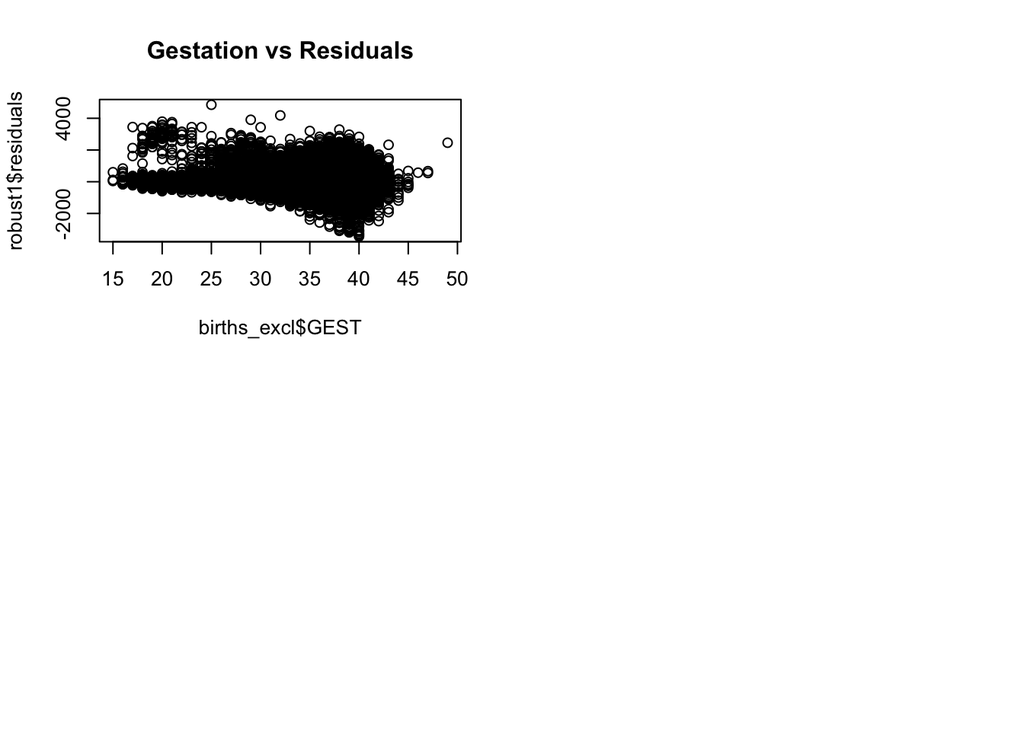

Our robust method downweights the weighting on observations with the largest residuals, as shown above. Looking at the output, it appears we still run into the same challenges as before with normality, even with this more robust approach. We will compare the approaches below by MSE using cross validation and splitting the data into test and training sets, but it is evident that an even more robust approach, such as quantile regression will be useful in exploring these relationships further.

### Cross Validation of Model

```
##               model1   model2   model3   model4  robust1
## Average MSE 180040.6 179938.2 176926.4 176401.3 176593.1
```

We employed K-fold cross-validation to test the models on their ability to accurately predict. Following the technique, we shuffled the data to randomize the sample, and then partitioned the data into K=10 folds (groups). We used the 10 folds to form 10 pairs of test and training sets; every test set is composed a differnet fold of the 10 total folds, and each training set is the remaining nine folds combined. We used the training sets to produce the estimates from the model, and use the test sets to produce an error score, the MSE. We averaged the 10 MSEs for all for 5 the models we developed and used this output as our metric of comparison.

We prefer using these MSE scores over the in-sample results reported in our initial model estimates. Using cross validation allows us to mitigate the adverse effects of overfitting our model by adding more covariates. As illustrated by the table above, model4 has the lowest MSE out of all models utilised. This implies that model4 yields the least erroneous out of sample (test data) results, and thus indicates the least amount of overfitting. Nonetheless, MSE is decreasing across our models as we increase the number of covariates and the MSE produced by cross-validation of model4 is not substantially lower than the lower-degree models. Therefore, although our preferred model exhibits the least amount of overfitting across all models we tested, we should explore further functional forms to see if we can noticeably decrease MSE. Notaby, the robust model had the second lowest MSE. The robust model reduces the influence of outlying data, therefore we will consider also solving for the MAE across our models as it may increase the interpretability of the robust error. This indicates that by attempting to reduce the influence of outlying data in our model, we may have begun to overfit the data.

## Interpretations and Conclusions

```
##
## Call:
## lm(formula = BWTG ~ SEX + GEST + GEST2 + GEST3 + GEST4 + PARITY_truncated +
##     PLUR_truncated + smoking_type + MAGE + MRACER + mortality,
##     data = births_excl, na.action = "na.exclude")
##
## Residuals:
##     Min      1Q  Median      3Q     Max
## -3459.5  -276.4   -19.1   254.2  4805.8
##
## Coefficients:
##                                 Estimate Std. Error  t value Pr(>|t|)
## (Intercept)                   -1.696e+04  7.563e+02  -22.430  < 2e-16 ***
## SEXMale                        1.250e+02  9.919e-01  126.038  < 2e-16 ***
## GEST                           2.759e+03  9.983e+01   27.641  < 2e-16 ***
## GEST2                         -1.624e+02  4.843e+00  -33.529  < 2e-16 ***
## GEST3                          4.134e+00  1.026e-01   40.299  < 2e-16 ***
## GEST4                         -3.707e-02  8.021e-04  -46.224  < 2e-16 ***
## PARITY_truncated2              8.560e+01  1.294e+00   66.168  < 2e-16 ***
## PARITY_truncated3              1.032e+02  1.512e+00   68.297  < 2e-16 ***
## PARITY_truncated4              1.080e+02  1.891e+00   57.110  < 2e-16 ***
## PARITY_truncated5+             1.110e+02  1.917e+00   57.905  < 2e-16 ***
## PLUR_truncated2               -3.130e+02  2.911e+00 -107.511  < 2e-16 ***
## PLUR_truncated3+              -3.212e+02  1.512e+01  -21.249  < 2e-16 ***
## smoking_typebefore and during -2.024e+02  1.734e+00 -116.729  < 2e-16 ***
## smoking_typebefore only       -1.070e+01  2.647e+00   -4.042 5.30e-05 ***
## smoking_typeduring only       -1.624e+02  8.941e+00  -18.168  < 2e-16 ***
## MAGE                           4.610e+00  9.442e-02   48.826  < 2e-16 ***
## MRACER1                        8.110e+01  1.625e+00   49.895  < 2e-16 ***
## MRACER2                       -9.986e+01  1.783e+00  -56.004  < 2e-16 ***
## MRACER3                       -2.682e+00  4.481e+00   -0.598   0.5496
## MRACER4                       -4.009e+01  7.445e+00   -5.384 7.27e-08 ***
## MRACER5                       -1.151e+02  1.757e+01   -6.551 5.70e-11 ***
## MRACER6                        1.988e+01  4.312e+01    0.461   0.6447
## MRACER7                       -2.249e+01  9.264e+00   -2.428   0.0152 *
## MRACER8                       -1.087e+02  3.142e+00  -34.603  < 2e-16 ***
## mortality                      1.886e+01  3.039e+00    6.207 5.41e-10 ***
## ---
## Signif. codes:  0 '***' 0.001 '**' 0.01 '*' 0.05 '.' 0.1 ' ' 1
##
## Residual standard error: 420 on 717844 degrees of freedom
## Multiple R-squared:  0.5381, Adjusted R-squared:  0.5381
## F-statistic: 3.484e+04 on 24 and 717844 DF,  p-value: < 2.2e-16
```